# HAR_Analysis

## Obtaining & cleaning data

Quote from the assignment:

“The data for this project come from this source: http://groupware.les.inf.puc-rio.br/har. If you use the document you create for this class for any purpose please cite them as they have been very generous in allowing their data to be used for this kind of assignment.”

So, let’s download the and save data from the provided url.

```r
ensure.data.presense <- function(url, target_filename) {
  if (!dir.exists("./data")) {
    dir.create("./data");
  }
  tf0 <- paste("./data", target_filename, sep = "/");
  if (!file.exists(tf0)) {
    tmp = tempfile(pattern = "src");
    download.file(url, tmp, mode = "wb");
    file.rename(tmp, tf0);
  }
}

ensure.data.presense("https://d396qusza40orc.cloudfront.net/predmachlearn/pml-training.csv", "pml-training.csv");
ensure.data.presense("https://d396qusza40orc.cloudfront.net/predmachlearn/pml-testing.csv", "pml-testing.csv");

nonNaColumns <- function(arg) {
  retVal <- c();
  for (name in names(arg)) {
    if (!all(is.na(c(arg[, name])))) {
      retVal <- c(retVal, name);
    }
  }
  retVal;
}

rawdata <- read.csv("./data/pml-training.csv", stringsAsFactors = FALSE);
rawdata_testing <- read.csv("./data/pml-testing.csv", stringsAsFactors = FALSE);
```

These datasets are relatively wide, 160 columns each. But it is obvious that model should pay attention only to variables which are included in the test set. After examining summary on the test table we could see that vast majority of the columns conatains NA values only. Also, it seems like testing dataset desn’t contain the “classe” variable which we should determine by our model while containing “problem_id”" column missing in the training set. Lets’ collect non-NA columns from the test data set and use them to take only relevant variables from the raw dataset.

```r
non.na.columns <- function(arg) {
  retVal <- c();
  for (name in names(arg)) {
    if (!all(is.na(c(arg[, name])))) {
      retVal <- c(retVal, name);
    }
  }
  retVal;
}
cols <- non.na.columns(rawdata_testing);
rawdata <- rawdata[, c("classe", cols[9:length(cols) - 1])]

processed <- with(rawdata, {
  data.frame(
    classe=as.factor(classe),
    roll_belt=as.numeric(roll_belt),
    pitch_belt=as.numeric(pitch_belt),
    yaw_belt=as.numeric(yaw_belt),
    total_accel_belt=as.numeric(total_accel_belt),
    gyros_belt_x=as.numeric(gyros_belt_x),
    gyros_belt_y=as.numeric(gyros_belt_y),
    gyros_belt_z=as.numeric(gyros_belt_z),
    accel_belt_x=as.numeric(accel_belt_x),
    accel_belt_y=as.numeric(accel_belt_y),
    accel_belt_z=as.numeric(accel_belt_z),
    magnet_belt_x=as.numeric(magnet_belt_x),
    magnet_belt_y=as.numeric(magnet_belt_y),
    magnet_belt_z=as.numeric(magnet_belt_z),
    roll_arm=as.numeric(roll_arm),
    pitch_arm=as.numeric(pitch_arm),
    yaw_arm=as.numeric(yaw_arm),
    total_accel_arm=as.numeric(total_accel_arm),
    gyros_arm_x=as.numeric(gyros_arm_x),
    gyros_arm_y=as.numeric(gyros_arm_y),
    gyros_arm_z=as.numeric(gyros_arm_z),
    accel_arm_x=as.numeric(accel_arm_x),
    accel_arm_y=as.numeric(accel_arm_y),
    accel_arm_z=as.numeric(accel_arm_z),
    magnet_arm_x=as.numeric(magnet_arm_x),
    magnet_arm_y=as.numeric(magnet_arm_y),
    magnet_arm_z=as.numeric(magnet_arm_z),
    roll_dumbbell=as.numeric(roll_dumbbell),
    pitch_dumbbell=as.numeric(pitch_dumbbell),
    yaw_dumbbell=as.numeric(yaw_dumbbell),
    total_accel_dumbbell=as.numeric(total_accel_dumbbell),
    gyros_dumbbell_x=as.numeric(gyros_dumbbell_x),
    gyros_dumbbell_y=as.numeric(gyros_dumbbell_y),
    gyros_dumbbell_z=as.numeric(gyros_dumbbell_z),
    accel_dumbbell_x=as.numeric(accel_dumbbell_x),
    accel_dumbbell_y=as.numeric(accel_dumbbell_y),
    accel_dumbbell_z=as.numeric(accel_dumbbell_z),
    magnet_dumbbell_x=as.numeric(magnet_dumbbell_x),
    magnet_dumbbell_y=as.numeric(magnet_dumbbell_y),
    magnet_dumbbell_z=as.numeric(magnet_dumbbell_z),
    roll_forearm=as.numeric(roll_forearm),
    pitch_forearm=as.numeric(pitch_forearm),
    yaw_forearm=as.numeric(yaw_forearm),
    total_accel_forearm=as.numeric(total_accel_forearm),
    gyros_forearm_x=as.numeric(gyros_forearm_x),
    gyros_forearm_y=as.numeric(gyros_forearm_y),
    gyros_forearm_z=as.numeric(gyros_forearm_z),
    accel_forearm_x=as.numeric(accel_forearm_x),
    accel_forearm_y=as.numeric(accel_forearm_y),
    accel_forearm_z=as.numeric(accel_forearm_z),
    magnet_forearm_x=as.numeric(magnet_forearm_x),
    magnet_forearm_y=as.numeric(magnet_forearm_y),
    magnet_forearm_z=as.numeric(magnet_forearm_z))
  });
```

The resulting dataset contains 53 variables.

## Exploratory data analysis

At first we must split dataset to training and testing sets before any exploration and work with training set only. The random seed is set to 31337.

```r
library(caret)
set.seed(31337)

inTrain <- createDataPartition(processed$classe, p = 0.7, list = FALSE);
training <- processed[inTrain,]
testing <- processed[-inTrain,]
```

53 variables is a still too big number, so let’s see if we could get rid of some of them.

```r
nearZeroVar(training, saveMetrics = TRUE)
```

```
##                      freqRatio percentUnique zeroVar   nzv
## classe                1.469526    0.03639805   FALSE FALSE
## roll_belt             1.119548    8.08036689   FALSE FALSE
## pitch_belt            1.006993   12.30982019   FALSE FALSE
## yaw_belt              1.054496   12.87762976   FALSE FALSE
## total_accel_belt      1.069014    0.21110868   FALSE FALSE
## gyros_belt_x          1.083070    0.93179006   FALSE FALSE
## gyros_belt_y          1.130525    0.48773386   FALSE FALSE
## gyros_belt_z          1.074074    1.19385601   FALSE FALSE
## accel_belt_x          1.056881    1.15745796   FALSE FALSE
## accel_belt_y          1.104545    1.00458615   FALSE FALSE
## accel_belt_z          1.026688    2.12564607   FALSE FALSE
## magnet_belt_x         1.023077    2.16204411   FALSE FALSE
## magnet_belt_y         1.072235    2.08924802   FALSE FALSE
## magnet_belt_z         1.018237    3.16663027   FALSE FALSE
## roll_arm             52.844444   17.48562277   FALSE FALSE
## pitch_arm            88.111111   20.40474631   FALSE FALSE
## yaw_arm              33.027778   19.06529810   FALSE FALSE
## total_accel_arm       1.089404    0.48045425   FALSE FALSE
## gyros_arm_x           1.008219    4.61527262   FALSE FALSE
## gyros_arm_y           1.490141    2.69345563   FALSE FALSE
## gyros_arm_z           1.092391    1.70342870   FALSE FALSE
## accel_arm_x           1.100000    5.54706268   FALSE FALSE
## accel_arm_y           1.225352    3.81451554   FALSE FALSE
## accel_arm_z           1.010638    5.55434229   FALSE FALSE
## magnet_arm_x          1.033333    9.61636456   FALSE FALSE
## magnet_arm_y          1.049180    6.27502366   FALSE FALSE
## magnet_arm_z          1.024691    9.12135110   FALSE FALSE
## roll_dumbbell         1.021053   86.39440926   FALSE FALSE
## pitch_dumbbell        2.103093   84.29060202   FALSE FALSE
## yaw_dumbbell          1.114943   85.84843852   FALSE FALSE
## total_accel_dumbbell  1.023884    0.30574361   FALSE FALSE
## gyros_dumbbell_x      1.031100    1.69614909   FALSE FALSE
## gyros_dumbbell_y      1.296296    1.92909660   FALSE FALSE
## gyros_dumbbell_z      1.110312    1.41224430   FALSE FALSE
## accel_dumbbell_x      1.022321    2.99919924   FALSE FALSE
## accel_dumbbell_y      1.022857    3.29038364   FALSE FALSE
## accel_dumbbell_z      1.116959    2.93368275   FALSE FALSE
## magnet_dumbbell_x     1.131148    7.78190289   FALSE FALSE
## magnet_dumbbell_y     1.155738    6.00567810   FALSE FALSE
## magnet_dumbbell_z     1.000000    4.79726287   FALSE FALSE
## roll_forearm         11.540084   13.77302177   FALSE FALSE
## pitch_forearm        62.159091   18.98522239   FALSE FALSE
## yaw_forearm          14.389474   12.79755405   FALSE FALSE
## total_accel_forearm   1.110604    0.49501347   FALSE FALSE
## gyros_forearm_x       1.120879    2.04557036   FALSE FALSE
## gyros_forearm_y       1.112360    5.29955594   FALSE FALSE
## gyros_forearm_z       1.164634    2.06740919   FALSE FALSE
## accel_forearm_x       1.029851    5.67809565   FALSE FALSE
## accel_forearm_y       1.028571    7.11945840   FALSE FALSE
## accel_forearm_z       1.036697    4.07658150   FALSE FALSE
## magnet_forearm_x      1.090909   10.64278955   FALSE FALSE
## magnet_forearm_y      1.100000   13.22705103   FALSE FALSE
## magnet_forearm_z      1.022727   11.77840868   FALSE FALSE
```

```r
cmx <- cor(training[,2:53])
names(training)[findCorrelation(cmx) + 1]
```

```
## [1] "accel_belt_z"     "roll_belt"        "accel_belt_y"
## [4] "accel_belt_x"     "gyros_dumbbell_x" "gyros_dumbbell_z"
## [7] "gyros_arm_x"
```

Let’s see if we could reduce dimension of the data while still keep most if its variance. By default caret package choose the threshold of 95%, but i’m going to set this explicitly here.

```r
pp <- preProcess(training[,2:53], method = "pca", thresh = 0.95)
harPC <- predict(pp, training[,2:53])
dim(harPC)
```

```
## [1] 13737    25
```

25 variables, that’s somewhat better.

Let’s look at first predictor capturing ~20% of the variance and take color from the activity class.

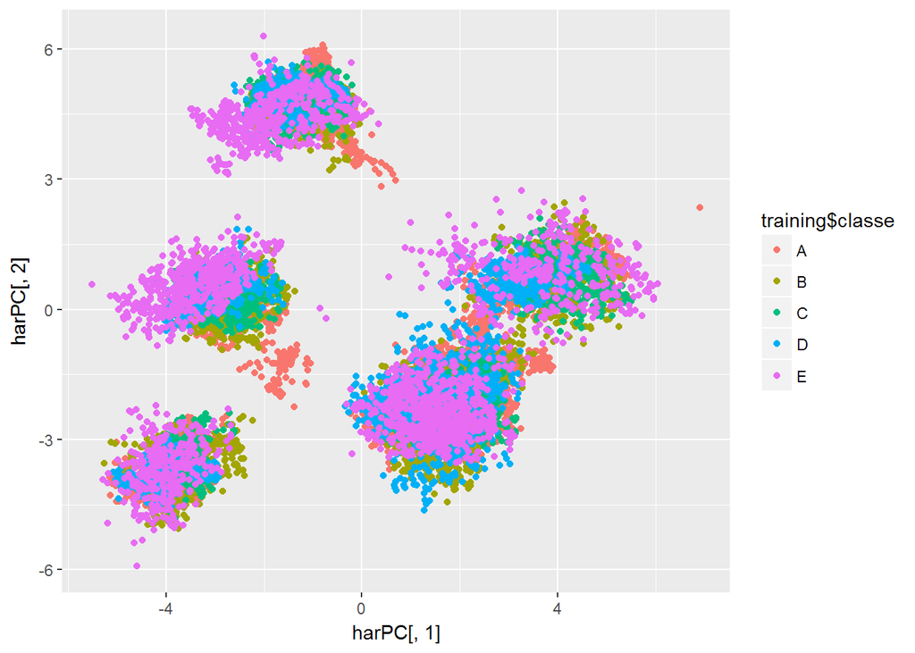

```r
qplot(harPC[,1], harPC[,2], col=training$classe)
```

## Model creation

According to exploratory analysis, the most troublesome part may be a D/E misclassification. The boosting method is known to deal with low-contrast features such as this.

```r
d.vs.e <- function(arg) {
  if (arg == "D")
    1
  else if (arg == "E")
    -1
  else 0
}

fvse <- sapply(training$classe, d.vs.e);
fvse.gbm <- train(harPC, fvse, method="gbm");
```

```r
fvse.pred <- predict(fvse.gbm, harPC)
ix0 <- which(abs(fvse) > 0);
confusionMatrix(sign(fvse.pred[ix0]), fvse[ix0])
```

```
## Confusion Matrix and Statistics
##
##           Reference
## Prediction   -1    1
##         -1 2315   99
##         1   210 2153
##
##                Accuracy : 0.9353
##                  95% CI : (0.928, 0.9421)
##     No Information Rate : 0.5286
##     P-Value [Acc > NIR] : < 2.2e-16
##
##                   Kappa : 0.8706
##  Mcnemar's Test P-Value : 3.907e-10
##
##             Sensitivity : 0.9168
##             Specificity : 0.9560
##          Pos Pred Value : 0.9590
##          Neg Pred Value : 0.9111
##              Prevalence : 0.5286
##          Detection Rate : 0.4846
##    Detection Prevalence : 0.5053
##       Balanced Accuracy : 0.9364
##
##        'Positive' Class : -1
##
```

Neural network is another option.

```r
fvse.nnet <- train(harPC, as.factor(fvse), method="nnet", trace = FALSE);
fvse.pred <- predict(fvse.nnet, harPC);
ix0 <- which(abs(fvse) > 0);
confusionMatrix(fvse.pred, fvse)
```

```
## Confusion Matrix and Statistics
##
##           Reference
## Prediction   -1    0    1
##         -1 1320  208   62
##         0  1041 8572  911
##         1   164  180 1279
##
## Overall Statistics
##
##                Accuracy : 0.8132
##                  95% CI : (0.8066, 0.8197)
##     No Information Rate : 0.6523
##     P-Value [Acc > NIR] : < 2.2e-16
##
##                   Kappa : 0.5936
##  Mcnemar's Test P-Value : < 2.2e-16
##
## Statistics by Class:
##
##                      Class: -1 Class: 0 Class: 1
## Sensitivity            0.52277   0.9567  0.56794
## Specificity            0.97592   0.5914  0.97005
## Pos Pred Value         0.83019   0.8145  0.78805
## Neg Pred Value         0.90080   0.8792  0.91968
## Prevalence             0.18381   0.6523  0.16394
## Detection Rate         0.09609   0.6240  0.09311
## Detection Prevalence   0.11575   0.7661  0.11815
## Balanced Accuracy      0.74935   0.7740  0.76899
```

The whole A/B/C/D/E model contains 5 categories, so it is possible to use a random forest here.

```r
ds1 <- cbind(data.frame(classe=training$classe, boosting=predict(fvse.gbm, harPC)), harPC);

model <- train(classe ~., data=ds1, method="rf", trace = FALSE);
```

```r
pred <- predict(model, ds1);
confusionMatrix(pred, ds1$classe)
```

```
## Confusion Matrix and Statistics
##
##           Reference
## Prediction    A    B    C    D    E
##          A 3906    0    0    0    0
##          B    0 2658    0    0    0
##          C    0    0 2396    0    0
##          D    0    0    0 2252    0
##          E    0    0    0    0 2525
##
## Overall Statistics
##
##                Accuracy : 1
##                  95% CI : (0.9997, 1)
##     No Information Rate : 0.2843
##     P-Value [Acc > NIR] : < 2.2e-16
##
##                   Kappa : 1
##  Mcnemar's Test P-Value : NA
##
## Statistics by Class:
##
##                      Class: A Class: B Class: C Class: D Class: E
## Sensitivity            1.0000   1.0000   1.0000   1.0000   1.0000
## Specificity            1.0000   1.0000   1.0000   1.0000   1.0000
## Pos Pred Value         1.0000   1.0000   1.0000   1.0000   1.0000
## Neg Pred Value         1.0000   1.0000   1.0000   1.0000   1.0000
## Prevalence             0.2843   0.1935   0.1744   0.1639   0.1838
## Detection Rate         0.2843   0.1935   0.1744   0.1639   0.1838
## Detection Prevalence   0.2843   0.1935   0.1744   0.1639   0.1838
## Balanced Accuracy      1.0000   1.0000   1.0000   1.0000   1.0000
```

The accuracy is 100%. This is too good to be true, so the data is probably overfitted. So it is time to run this model on a test dataset.

```r
harPC.test <- predict(pp, testing[,2:53])
ds1.test <- cbind(data.frame(classe=testing$classe, boosting=predict(fvse.gbm, harPC.test)), harPC.test);
pred <- predict(model, ds1.test);
confusionMatrix(pred, ds1.test$classe)
```

```
## Confusion Matrix and Statistics
##
##           Reference
## Prediction    A    B    C    D    E
##          A 1659   16    0    3    4
##          B    3 1105   23    0    6
##          C    8   14  980   51    3
##          D    3    0   16  908    9
##          E    1    4    7    2 1060
##
## Overall Statistics
##
##                Accuracy : 0.9706
##                  95% CI : (0.966, 0.9748)
##     No Information Rate : 0.2845
##     P-Value [Acc > NIR] : < 2.2e-16
##
##                   Kappa : 0.9628
##  Mcnemar's Test P-Value : NA
##
## Statistics by Class:
##
##                      Class: A Class: B Class: C Class: D Class: E
## Sensitivity            0.9910   0.9701   0.9552   0.9419   0.9797
## Specificity            0.9945   0.9933   0.9844   0.9943   0.9971
## Pos Pred Value         0.9863   0.9719   0.9280   0.9701   0.9870
## Neg Pred Value         0.9964   0.9928   0.9905   0.9887   0.9954
## Prevalence             0.2845   0.1935   0.1743   0.1638   0.1839
## Detection Rate         0.2819   0.1878   0.1665   0.1543   0.1801
## Detection Prevalence   0.2858   0.1932   0.1794   0.1590   0.1825
## Balanced Accuracy      0.9928   0.9817   0.9698   0.9681   0.9884
```

Testing dataset shows accuracy of ~97%, which is pretty acceptable for this educational task.

## Conlcusion

This works covers usege of the few basic caret facilities - data partitioning, singular value decomposition and three classificational facilities - boosting, random forest and neural network.